# Proyecto_GWAS_clase14

```r
library(utils)
library(rrBLUP)
library(ggplot2)
```

## Importe el archivo de genotipos geno.txt y fenotipos Pheno.txt

```r
geno <- read.delim("geno.txt", sep = "\t", dec = ",", header = T)
pheno <- read.delim("pheno.txt", sep = "\t", dec = ",", header = T)
```

## Exploración de datos

```r
head(geno)
```

|  | marker | chrom | pos | animal_1 | animal_2 | animal_3 | animal_4 | animal_5 | animal_6 | animal_7 | animal_8 | animal_9 | animal_10 | animal_11 | animal_12 | animal_13 | animal_14 | animal_15 | animal_16 | animal_17 | animal_18 | animal_19 | animal_20 | animal_21 | animal_22 | animal_23 | animal_24 | animal_25 | animal_26 | … |
| --- | --- | --- | --- | --- | --- | --- | --- | --- | --- | --- | --- | --- | --- | --- | --- | --- | --- | --- | --- | --- | --- | --- | --- | --- | --- | --- | --- | --- | --- | --- |
| 1 | snp1 | 1 | 1 | 1 | 0 | 1 | 0 | 1 | 0 | -1 | 0 | -1 | 0 | 0 | 0 | -1 | 1 | 1 | 1 | 1 | 0 | 0 | 1 | 1 | 0 | 0 | 0 | 1 | 0 | … |
| 2 | snp2 | 1 | 2 | 0 | 0 | -1 | -1 | 0 | 0 | -1 | 0 | 0 | 0 | 0 | 0 | 0 | 1 | -1 | -1 | 0 | 0 | -1 | 0 | -1 | -1 | 1 | -1 | 0 | 0 | … |
| 3 | snp3 | 1 | 3 | 0 | 0 | -1 | 1 | -1 | 0 | 0 | 0 | 1 | 0 | 0 | -1 | 1 | 1 | 0 | 1 | 0 | 1 | 0 | 0 | 0 | -1 | 0 | 1 | -1 | 0 | … |
| 4 | snp4 | 1 | 4 | -1 | 0 | 0 | 1 | -1 | 0 | 1 | 0 | -1 | 0 | -1 | -1 | 0 | 0 | 0 | -1 | 0 | 0 | 0 | 0 | 0 | 1 | -1 | 0 | 0 | 0 | … |
| 5 | snp5 | 1 | 5 | 0 | 0 | 1 | 0 | -1 | 0 | 1 | -1 | 0 | 1 | 0 | 0 | 0 | 0 | 1 | 0 | -1 | 0 | -1 | 1 | 1 | -1 | -1 | 0 | 1 | 0 | … |
| 6 | snp6 | 1 | 6 | 1 | 0 | -1 | -1 | -1 | 1 | 0 | -1 | -1 | 0 | -1 | 0 | 0 | 1 | 1 | 0 | 1 | 1 | -1 | -1 | -1 | -1 | 0 | 0 | -1 | -1 | … |

```r
dim(pheno)
```

```
## [1] 200   2
```

```r
head(geno[1:6,1:6])
```

|  | marker | chrom | pos | animal_1 | animal_2 | animal_3 |
| --- | --- | --- | --- | --- | --- | --- |
| 1 | snp1 | 1 | 1 | 1 | 0 | 1 |
| 2 | snp2 | 1 | 2 | 0 | 0 | -1 |
| 3 | snp3 | 1 | 3 | 0 | 0 | -1 |
| 4 | snp4 | 1 | 4 | -1 | 0 | 0 |
| 5 | snp5 | 1 | 5 | 0 | 0 | 1 |
| 6 | snp6 | 1 | 6 | 1 | 0 | -1 |

```r
head(pheno)
```

|  | animal | y |
| --- | --- | --- |
| 1 | animal_1 | 2.52813203 |
| 2 | animal_2 | 1.44348297 |
| 3 | animal_3 | 1.11555299 |
| 4 | animal_4 | 2.01623154 |
| 5 | animal_5 | 0.08267191 |
| 6 | animal_6 | 1.80765254 |

## ¿Cómo están codificados los genotipos de cada SNP?

Los genotipos están codificados como (-1, 0 y 1). Dónde (-1, 0 y 1) hace referencia al homocigoto del alelo menor, heterocigoto, homocigoto del alelo mayor, respectivamente.

## ¿Observa heterocigotos?

Si se evidencia heterocigotos en los tres individuos analizados. Sin embargo, el individuo 2 es el organismo con mayor heterocigotos

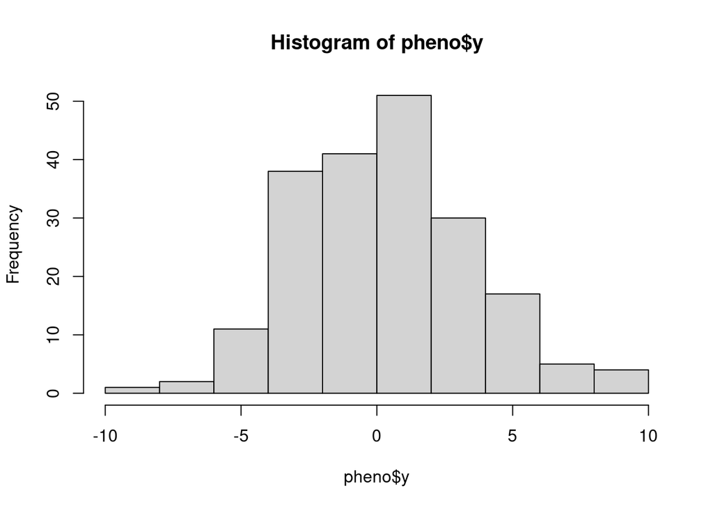

```r
hist(pheno$y)
```

```r
A <- A.mat(geno[4:203])
dim(A)
```

```
## [1] 1000 1000
```

```r
head(A[1:6,1:6])
```

```
##             [,1]        [,2]        [,3]        [,4]        [,5]        [,6]
## [1,]  1.09783609  0.03753355 -0.03269311 -0.04195663  0.06084240 -0.02389977
## [2,]  0.03753355  0.98799439 -0.10261966 -0.07186798 -0.08911453 -0.02379974
## [3,] -0.03269311 -0.10261966  0.98759424 -0.18210984  0.05073856  0.06603437
## [4,] -0.04195663 -0.07186798 -0.18210984  1.04909759  0.03147125  0.07677845
## [5,]  0.06084240 -0.08911453  0.05073856  0.03147125  1.05461969 -0.07051747
## [6,] -0.02389977 -0.02379974  0.06603437  0.07677845 -0.07051747  1.05519991
```

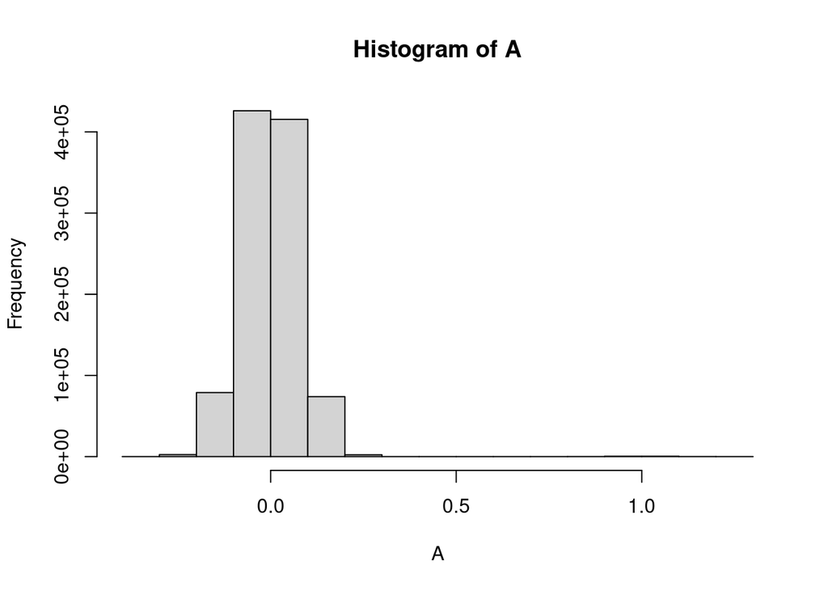

```r
hist(A)
```

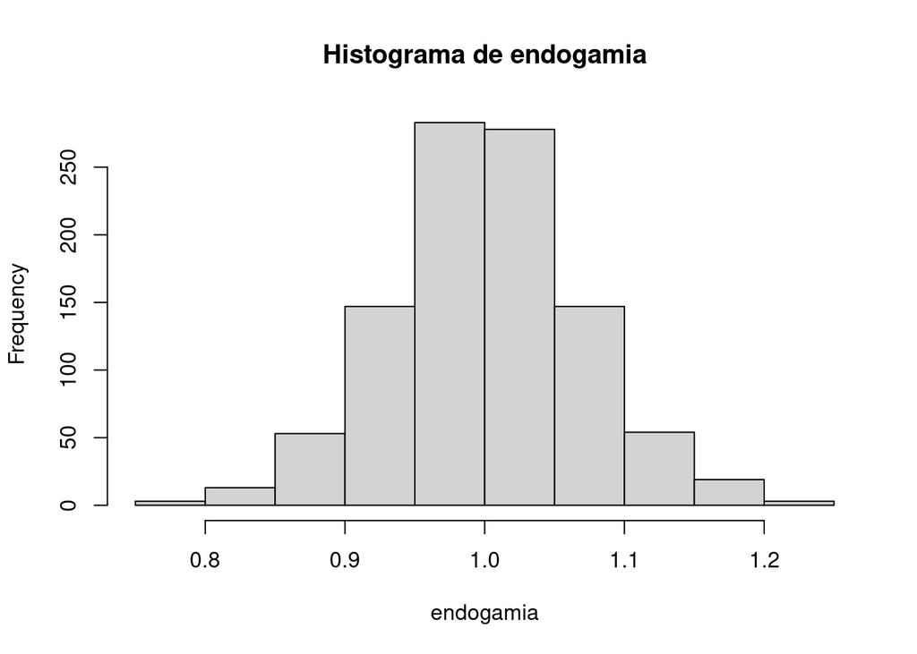

```r
endogamia <- diag(A)
hist(endogamia, main = "Histograma de endogamia")
```

```r
score <- GWAS(pheno,geno, plot=TRUE)
```

[output not shown]

```
## [1] "GWAS for trait: y"
## [1] "Variance components estimated. Testing markers."
```

## ¿Cuál es el nivel de endogamia promedio de esta población?

El nivel de endogamia promedio de esta población es de (1), debido a que claramente ilustra el histograma que los valores fluctúan aproximadamente de 0.75 a 1.25

## ¿Que significa un valor de endogamia de 1.1?

El valor de (1.1) nos indica una mayor probabilidad del (10%) de incremento de endogamia en la población respecto al promedio de la población.

## ¿Que representa un valor de endogamia de 0.90?

El valor de (0.9) nos indica una menor probabilidad del (10%) en reducir la endogamia en la población respecto al promedio de la población.

## Visualmente: ¿Cuantos QTLs fueron detectados por el análisis GWAS? ¿En qué cromosomas se encuentran?

```r
class(score)
```

```
## [1] "data.frame"
```

## exploración del efecto de los QTLs detectados por el GWAS

```r
head(score)
```

|  | marker | chrom | pos | y |
| --- | --- | --- | --- | --- |
| 1 | snp1 | 1 | 1 | 0.27068411 |
| 2 | snp2 | 1 | 2 | 0.09321965 |
| 3 | snp3 | 1 | 3 | 1.00621907 |
| 4 | snp4 | 1 | 4 | 0.22399674 |
| 5 | snp5 | 1 | 5 | 0.40095387 |
| 6 | snp6 | 1 | 6 | 1.91710405 |

## ¿Qué SNP fueron significativos?

```r
dplyr::filter(score, y > 5)
```

| marker | chrom | pos | y |
| --- | --- | --- | --- |
| snp300 | 3 | 100 | 7.504724 |
| snp1000 | 10 | 100 | 8.508100 |

## ¿Con que nivel de significancia se concluye que fueron significativos?. * Sugerencia note que el score corresponde a -log(p), donde p es la probabilidad o significancia

```r
exp(-7.5047236)
```

```
## [1] 0.000550478
```

```r
exp(-8.5080997)
```

```
## [1] 0.000201827
```

## gráfico de regresión lineal de fenotipo en función de los genotipo para cada SNP significativo

```r
t_geno_300 <- t(geno[300,4:203])+1
t_geno_1000 <- t(geno[1000,4:203])+1
qtl <- data.frame(t_geno_300,t_geno_1000,pheno$y)
head(qtl)
```

|  | X300 | X1000 | pheno.y |
| --- | --- | --- | --- |
| animal_1 | 1 | 1 | 2.52813203 |
| animal_2 | 2 | 0 | 1.44348297 |
| animal_3 | 1 | 1 | 1.11555299 |
| animal_4 | 1 | 1 | 2.01623154 |
| animal_5 | 1 | 0 | 0.08267191 |
| animal_6 | 0 | 2 | 1.80765254 |

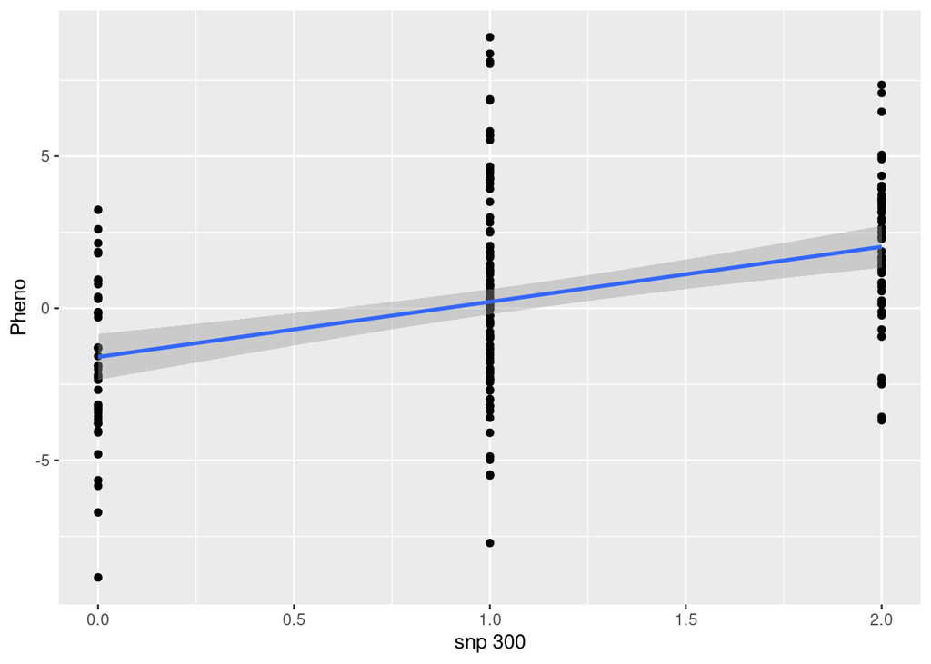

```r
qtl.1 <- ggplot(qtl, aes(x = X300, y = pheno.y))
qtl.1 + geom_point() + xlab("snp 300") +  ylab("Pheno")+ geom_smooth(method=lm)
```

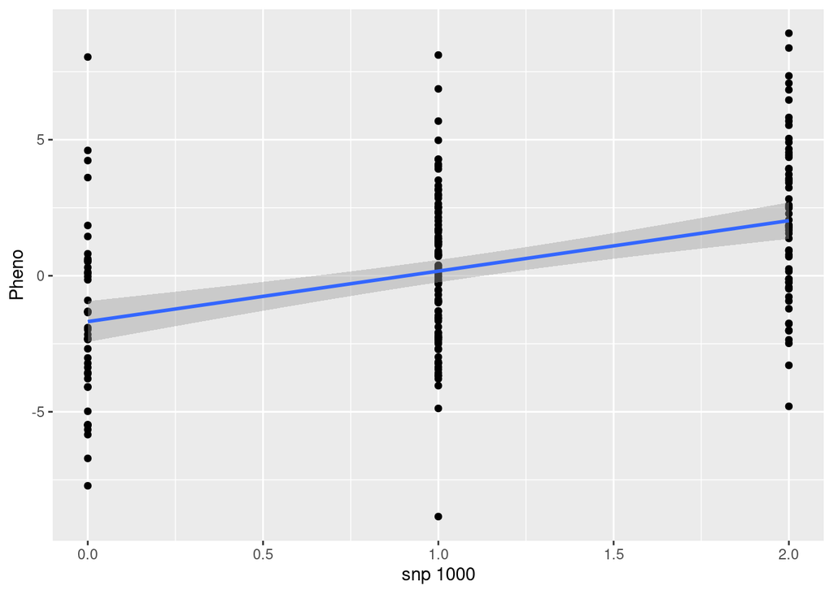

```r
qtl.2 <- ggplot(qtl, aes(x = X1000, y = pheno.y))
qtl.2 + geom_point() + xlab("snp 1000") +  ylab("Pheno")+ geom_smooth(method=lm)
```

## Estimación del efecto (beta o pendiente) de los QTLs con mayor score usando un modelo lineal

```r
lm.qtl.300 <- lm(pheno.y ~ X300, data = qtl)
summary(lm.qtl.300)
```

```
##
## Call:
## lm(formula = pheno.y ~ X300, data = qtl)
##
## Residuals:
##     Min      1Q  Median      3Q     Max
## -7.9292 -1.9076 -0.2454  1.5984  8.7040
##
## Coefficients:
##             Estimate Std. Error t value Pr(>|t|)
## (Intercept)  -1.6019     0.3831  -4.181 4.35e-05 ***
## X300          1.8121     0.3015   6.011 8.72e-09 ***
## ---
## Signif. codes:  0 '***' 0.001 '**' 0.01 '*' 0.05 '.' 0.1 ' ' 1
##
## Residual standard error: 2.956 on 198 degrees of freedom
## Multiple R-squared:  0.1543, Adjusted R-squared:  0.1501
## F-statistic: 36.13 on 1 and 198 DF,  p-value: 8.717e-09
```

```r
cat("El efecto del snp300 sobre el rasgo cuantitativo 1.8121")
```

```
## El efecto del snp300 sobre el rasgo cuantitativo 1.8121
```

```r
lm.qtl.1000 <- lm(pheno.y ~ X1000, data = qtl)
summary(lm.qtl.1000)
```

```
##
## Call:
## lm(formula = pheno.y ~ X1000, data = qtl)
##
## Residuals:
##     Min      1Q  Median      3Q     Max
## -9.0213 -2.2599 -0.1655  1.9001  9.7233
##
## Coefficients:
##             Estimate Std. Error t value Pr(>|t|)
## (Intercept)  -1.6845     0.3805  -4.428 1.57e-05 ***
## X1000         1.8549     0.2940   6.310 1.79e-09 ***
## ---
## Signif. codes:  0 '***' 0.001 '**' 0.01 '*' 0.05 '.' 0.1 ' ' 1
##
## Residual standard error: 2.933 on 198 degrees of freedom
## Multiple R-squared:  0.1674, Adjusted R-squared:  0.1632
## F-statistic: 39.81 on 1 and 198 DF,  p-value: 1.792e-09
```

```r
cat("El efecto del snp1000 sobre el rasgo cuantitativo 1.8549")
```

```
## El efecto del snp1000 sobre el rasgo cuantitativo 1.8549
```